# Causal Inference of Labor Market Inequality Using PGM: A multidimensional analysis of unemployment rate

### 3.2 Unemployment Rates of Differenet Industries

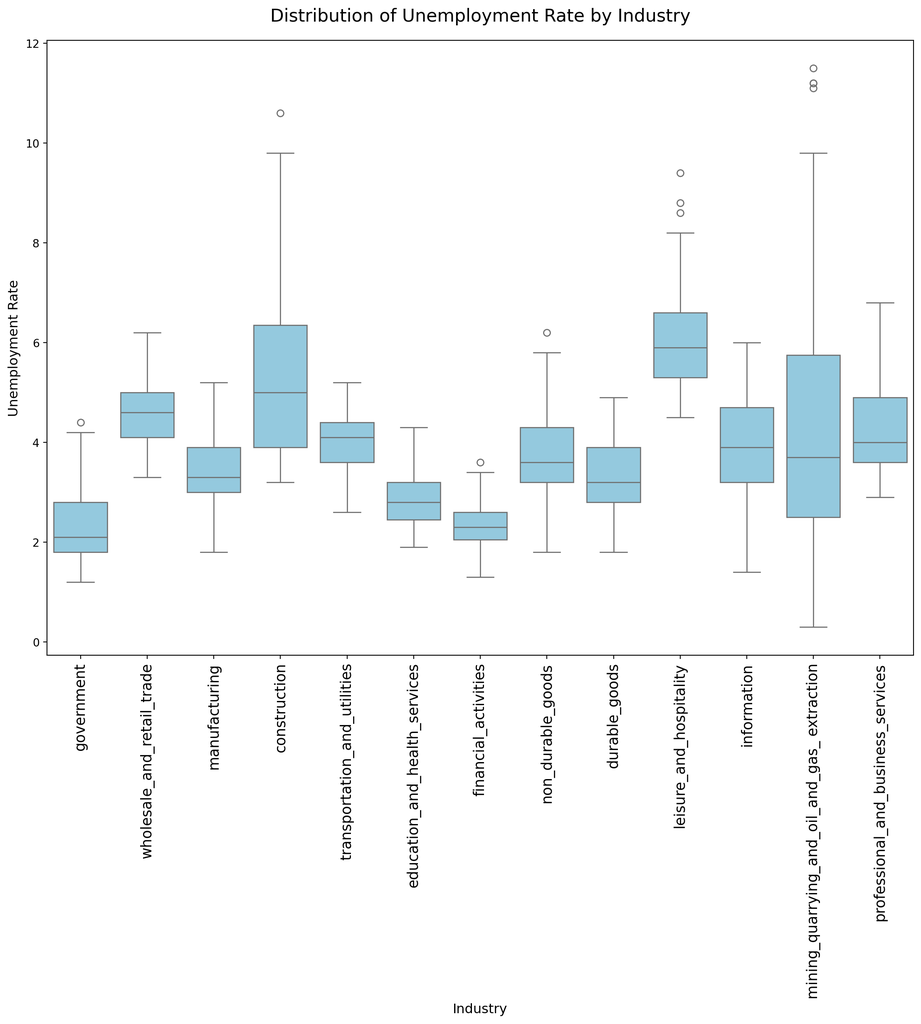

Figure 4: Unemployment Rate Distributions By Industries (2015-2025 statistics)

The boxplot illustrates notable variation in unemployment rates across industries. “Agricultural, mining/oil/gas extraction” and “Construction” industries exhibit the highest variation and upper extremes, indicating greater instability in employment. Due to the volatility and unpredictivity as a result of seasonlity, these two categories are going to be excluded from our analysis. In contrast, “Government”, “Financial services”, and “Education/health services” show consistently low and stable unemployment rates, with narrower interquartile ranges and fewer outliers. These patterns suggest structural differences in labor market vulnerability across sectors. (Figure 4).

## 4 PGM

We posit that unemployment vulnerability is driven by structural inequalities within the labor market, particularly those rooted in demographic and industrial dimensions. Demographic disparities are represented by variables such as race, age, and educational attainment and industry; sex is excluded from the analysis due to prior findings indicating minimal impact on unemployment rates. Establishing a baseline unemployment level is a necessary step before assessing the marginal effects of these demographic and industrial factors.